# 比較兩組連續結果並檢查結論

Week 09｜Part 2 概念

HT3001B 生物統計學與 R

2026-11-05

## 兩組差多少？先問誰和誰比

同樣量血壓，問題可以不同：

| 問題 | 需要保留的關係 |
| --- | --- |
| 年齡與血壓一起變動嗎？ | 兩個數值變項的關聯 |
| 介入組與對照組平均差多少？ | 分組與數值結果 |
| 同一人介入前後平均改變多少？ | 每個人的前後配對 |

**先辨認問題與觀察單位，再挑方法。**

IMS 2e Ch20–21

## 先固定差的方向與單位

以「介入組 − 對照組」為例：

$$\Delta=\mu_I-\mu_C,\qquad \widehat{\Delta}=\bar{x}_I-\bar{x}_C$$

- $\Delta$：想了解的母體平均數差（difference in means）。
- $\widehat{\Delta}$：用樣本估計的差；單位仍是 mmHg。
- 若量的是「後 − 前」的血壓變化，負值代表下降。

**平均差 −8 mmHg，和「下降 8%」不同。**

IMS 2e Ch20–21

## 獨立還是配對？看資料怎麼來

[figure not shown]

左側兩群不同的人；右側同一人兩次量測由線連結。

**獨立樣本（independent samples）**：不同個體，沒有自然一對一對應。  
**配對資料（paired data）**：同一人或事先配成的一對，有明確對應。

IMS 2e Ch20–21

## 先對每個人相減，再平均

差的方向固定為「後 − 前」（mmHg）。

| 人 | 前 | 後 | 個人差 $d_i$ |
| --- | --- | --- | --- |
| 甲 | 128 | 122 | −6 |
| 乙 | 142 | 140 | −2 |
| 丙 | 136 | 132 | −4 |

$$\bar d=(-6-2-4)/3=-4\ \text{mmHg}$$

**三個人、三個差；不是六個獨立個體。**

IMS 2e Ch21、§21.3

## 相減後，才看差異有多分散

[figure not shown]

同一人的前後值以線連起；右側改畫三個個人差。

- 配對 t 檢定（paired t-test）針對**個人差的平均**。
- SE 使用個人差的標準差（standard deviation, SD）。

IMS 2e Ch21、§21.3

## 回顧：已知 σ 時，用 Z 衡量差異

量表案例：$n=64$、$\mu_0=25$、已知 $\sigma=6$、樣本平均 $\bar x=23$。

$$SE=\frac{6}{\sqrt{64}}=0.75,\qquad z=\frac{23-25}{0.75}=-2.67$$

- 分子是與基準的差，分母是平均數的標準誤（standard error）。
- 在常態模型及 $H_0$ 下，用標準常態分布（standard normal distribution）判讀。
- 若母體 σ 不知道，分母也要由樣本估計。這會改變什麼？

IMS 2e §13.3、§19.2；沿用 Week 7 教學案例

## 用 s 估計 σ，多一層不確定

$$t=\frac{\bar x-\mu_0}{s/\sqrt n}$$

單樣本獨立常態觀察下，$H_0$ 成立時服從自由度 $n-1$ 的 t 分布（t-distribution）。

- 樣本平均與樣本 SD 都會隨抽樣變動。
- 小自由度的尾部較厚，容許更多遠離零的值。
- 自由度（degrees of freedom）增加時，逐漸接近標準常態。

IMS 2e §19.2

## 同樣標準化，尾端機率仍會不同

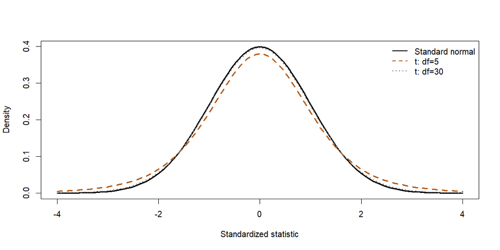

黑實線為標準常態，橘虛線為 df＝5 的 t；小自由度 t 分布的尾部較厚。

比較相同橫軸值的尾端，不能只看曲線中央。

IMS 2e §19.2；自製圖，week09_r4.R

## 95% 區間：t* 取代固定的 1.96

$$\bar x\ \pm\ t^*\frac{s}{\sqrt n}$$

| 自由度 | 5 | 10 | 30 | 100 | 標準常態 |
| --- | --- | --- | --- | --- | --- |
| 雙尾 95% 乘數 | 2.571 | 2.228 | 2.042 | 1.984 | 1.960 |

**估計越不穩定，區間需要反映這層不確定。**

IMS 2e §19.2；R qt，數值已由本週 R 程式核對

## 配對 t：把每一對化成一個差

令 $d_i=\text{後}_i-\text{前}_i$；檢驗 $H_0:\mu_d=0$。

$$t=\frac{\bar d}{s_d/\sqrt n},\quad df=n-1,\quad CI=\bar d\pm t^*\frac{s_d}{\sqrt n}$$

- $n$ 是完整配對數，$s_d$ 是個人差的 SD。
- 各對彼此獨立，小樣本時要檢查差值分布與極端值。
- 有人缺後測：先記錄缺失，再按完整配對分析並交代限制。

IMS 2e §20.3、§21.3

## 兩組獨立、比較平均：認識 Welch t

Welch t 檢定（Welch’s t-test）：

- 比較兩個**獨立組**的母體平均數。
- 分別估計兩組變異，**不要求兩組母體變異相等**。
- 依兩組變異與樣本數調整自由度（degrees of freedom）。

**它仍需要合理的抽樣／獨立性與分布條件。**  
不等變異可以處理，不代表極端值、偏態或相依性都已解決。

IMS 2e §20.3；[R Documentation: t.test](https://stat.ethz.ch/R-manual/R-devel/library/stats/html/t.test.html)

## Welch 的尺度：差異相對於不確定性

在「母體平均差為 0」的虛無假設下：

$$t=\frac{(\bar x_I-\bar x_C)-0}{\sqrt{s_I^2/n_I+s_C^2/n_C}}$$

- 分子：觀察到的平均差。
- 分母：平均差的標準誤（standard error, SE）。
- 同樣的差，若估計更不穩定，$|t|$ 會較小。

**兩組各保留自己的變異與樣本數。**

IMS 2e §20.3；[R Documentation: t.test](https://stat.ethz.ch/R-manual/R-devel/library/stats/html/t.test.html)

## 練習 1｜差一樣，證據強度也一樣嗎？

兩項自編研究都得到平均差 −8 mmHg。

| 研究 | 平均差的 SE | $t$ |
| --- | --- | --- |
| A | 2 mmHg | −4 |
| B | 8 mmHg | −1 |

**不一樣。**A 的差相對於估計不確定性較大。要算 p 值，還要知道適用的參考分布與自由度；不能只憑差的大小或 t 值決定實質重要性。

IMS 2e §20.3；[R Documentation: t.test](https://stat.ethz.ch/R-manual/R-devel/library/stats/html/t.test.html)

## 平均差的區間，先用原始單位讀

`births14`：不吸菸組平均 − 吸菸組平均。

$$\widehat\Delta=0.593\ \text{lb},\quad 95\%\ CI=(0.285,\ 0.900)\ \text{lb}$$

- Welch：$t=3.817$，$df=131.306$，$p=0.000208$。
- 區間描述母體平均差的不確定性，不是 95% 個體的體重範圍。
- 這是觀察資料；本分析無法直接把差歸因於吸菸。

IMS 2e §20.3；OpenIntro births14；verification/r4_results.csv

## 效果量 d：明訂用合併 SD

$$s_p=\sqrt{\frac{(n_1-1)s_1^2+(n_2-1)s_2^2}{n_1+n_2-2}},\qquad d=\frac{\bar x_1-\bar x_2}{s_p}$$

- 合併標準差（pooled SD）把平均差轉為 SD 單位。
- 出生體重例：$d\approx0.463$，方向仍為不吸菸減吸菸。
- 這是效果量分母的約定；主分析仍採 Welch 的 SE。
- 實質重要性還要結合單位、情境與事先設定的重要差異。

Week 5 效果量概念；本週合併 SD 約定；verification/r4_extra.csv

## 條件檢查：設計、分布與完整配對

| 問題 | 檢查依據 |
| --- | --- |
| 觀察是否獨立？ | 抽樣／分派方式、群聚或重複量測 |
| 小樣本、偏態、極端值？ | 原始點圖、盒形圖、直方圖 |
| 配對是否完整且對應正確？ | 同一個體識別、前後欄位、缺失紀錄 |

獨立性來自設計；常態檢定的 p 值不能替代上述判斷。

IMS 2e §20.3、§21.3

## 置換前，先說清楚什麼能交換

置換檢定（permutation test）重排標籤，產生虛無分布（null distribution）。

本例是完全隨機分派的六人實驗，每組三人：

1. 假定每人的結果不受分派影響。
2. 保留六個結果，依原設計重分兩組。
3. 每次計算平均差，與實際平均差比較。

**這個「每人都不受影響」的假設，比母體平均相等更強。**

IMS 2e §11.1、11.3、20.1

## 六個人：一次看完所有可能分派

自編示意：結果是「後 − 前」的血壓變化。

| 實際分組 | 三人的變化（mmHg） | 平均 |
| --- | --- | --- |
| 介入 I | −8、−6、−4 | −6 |
| 對照 C | 0、2、4 | 2 |

$$T_{\mathrm{obs}}=\bar x_I-\bar x_C=-8\ \text{mmHg}$$

六人中選三人進介入組，共 $\binom{6}{3}=20$ 種等機率分派。

IMS 2e §11.1、11.3、20.1

## 雙尾：把兩個方向的極端都算進去

[figure not shown]

20種分派的平均差點圖；左右各一個橘點滿足絕對值至少8。

$$p=\frac{\#\{|T|\ge|T_{\mathrm{obs}}|\}}{20}=\frac{2}{20}=0.10$$

這裡完整枚舉 20 種分派，包含實際分派。

IMS 2e §11.1、11.3、14.2、20.1

## 配對的重排，仍要保留配對

配對內隨機分派兩種條件時，虛無模型允許在**同一對內**交換標籤。

- 每一對仍各有一個條件 A 與 B。
- 交換相當於把該對的差 $d_i$ 改為 $-d_i$。
- 不可把甲的前測和乙的後測混在一起。

**固定先後順序的前後測，不能只因有配對，就任意翻差的正負號。**  
需要分派機制或適當的模型假設支持。

IMS 2e §21.1

## 平均相同，就能任意洗牌嗎？

不一定。可交換性（exchangeability）需要設計或模型支持。

- 隨機分派實驗：重排應遵守原分派規則與檢驗的虛無假設。
- 觀察性兩組：直接混合標籤，需要額外分布／可交換假設。
- 只有「平均相等」，不保證兩組分布相同。
- 不等變異又樣本數不平衡時，原始平均差直接洗牌可能失準。

**置換不等於無條件、無假設。**

IMS 2e §11.1、20.1；[Chung & Romano（2013）](https://arxiv.org/abs/1304.5939)

## 一個極端值，先改變了哪個摘要？

五筆等候時間（自編）：2、3、4、5、26 分鐘。

| 摘要 | 平均數 | 中位數 | 兩端各去一筆的截尾平均 |
| --- | --- | --- | --- |
| 數值 | 8 | 4 | 4 |

資料品質有問題，先查來源；若改用穩健（robust）摘要，要說明估計目標與理由。

**保留分析前的選擇，避免依結果挑選方法。**

IMS 2e §5.1；自編例

## Wilcoxon：先比較它回答的問題

| 資料結構 | 方法 | 關注的問題 |
| --- | --- | --- |
| 兩獨立組 | 秩和檢定（rank-sum） | 在位置位移模型下比較分布位置 |
| 同人前後 | 符號等級檢定（signed-rank） | 差值分布是否以指定值為對稱中心 |

- 秩方法（rank-based methods）使用排序；結果不直接檢驗平均差。
- 中位數的解讀需要額外分布條件。
- 改用方法仍需保留獨立性、配對及適用條件。

R 官方 stats::wilcox.test 說明；R4 示範採 exact=FALSE

## 練習 2｜只改一個細節，方法會改嗎？

三個自編情境，結果都是數值血壓：

1. 不同受試者隨機分派到介入／對照，各量一次。
2. 同一批人，介入前後各量一次。
3. 不同門診的既有病人，自行選擇是否接受介入。

請各說出：**分析單位、是否配對、平均差的方法起點、因果限制。**

1：人、獨立、Welch 起點；因果推論需符合隨機實驗條件。2：人／對、配對、分析個人差；時間變化仍可能混淆。3：人、獨立起點但需查門診群聚；自選介入有混淆，不能直接讀成因果。

IMS 2e Ch20–21

## 練習 3｜缺三個後測，n 還是一樣嗎？

20 人各量前後血壓；其中 3 人缺後測。若採完整配對的平均改變分析：

1. 分析中有幾個差？自由度為多少？
2. 與兩組不同的人各 20 位比較，有何差別？
3. 缺失是否可能與結果有關？

可用 17 個完整差，配對 t 的 df＝16；兩獨立組沒有前後一對一關係。完整配對分析不會自動消除缺失偏誤。

IMS 2e §20.3、§21.3；自編練習

## Part Two Quiz｜比較兩組平均

概念題 1–3，單選，每題 45 秒。

[**開啟 Slido 作答頁**](https://app.sli.do/event/1jvhioqZKKM7xUwqNzn4av) · 活動代碼 **2249905**

[figure not shown]

第九週 Slido 作答入口 QR code。

[第九週 Slido](https://app.sli.do/event/1jvhioqZKKM7xUwqNzn4av)；Part Two｜比較兩組平均

## Slido 1｜配對之後，n 是多少？

同一批 30 人各量一次介入前與介入後血壓，想比較平均改變。哪個分析起點最合理？

1. 把 60 次量測當作 60 位獨立受試者
2. 保留每人的前後對應，以 30 個個人差分析
3. 因為前後人數相等，就隨機重新配對
4. 只比較兩欄的最大值

**答案：B。**分析單位是人／配對；同一人兩次量測仍形成一個個人差。人數相同本身不構成配對。

IMS 2e §21.3；本週配對資料概念

## Slido 2｜Welch 能處理哪個問題？

兩個獨立樣本比較平均收縮壓，樣本數與變異不同；病人自行選擇門診。哪個分析與解釋最合理？

1. 改用配對分析，讓兩組人數一樣
2. 直接混合標籤置換，因為置換沒有假設
3. p 值小，就表示門診造成血壓差異
4. 獨立性及分布條件適用時考慮 Welch t，並保留觀察研究的因果限制

**答案：D。**Welch 分別估計兩組變異，但仍需獨立性與分布條件。自行選擇門診可能有混淆，不能從小 p 值直接推論因果。

IMS 2e §20.3；本週 Welch 與推論界線

## Slido 3｜平均相等，就能任意洗牌嗎？

觀察性資料的兩組平均相等，但樣本數不平衡、變異也不同。直接混合標籤、以原始平均差做置換檢定，哪句話正確？

1. 平均相等就保證所有標籤可交換
2. 重排次數夠多就能消除設計偏誤
3. 還需設計或可交換性假設；僅平均相等不足以支持任意重排
4. 改做配對內交換，便不需要任何額外條件

**答案：C。**平均相等不保證分布相同；原始平均差的標籤置換仍需設計或模型支持。不等變異且樣本數不平衡時尤其要留意。

IMS 2e §20.1；本週可交換性與方法條件

## 把方法、效果與推論界線連起來

**研究問題 → 資料結構 → 圖與摘要 → 方法與條件 → 結論**

- 原始單位：差多少、往哪個方向？
- 信賴區間（confidence interval）：估計有多不確定？
- 檢定：資料與指定的虛無模型多不相容？
- 推論：可推廣到誰？能否談因果？

接續 R 實習 4 · 課本圖例

IMS 2e Ch20–21；本週整合

## 課本圖例｜獨立兩組的原始分數

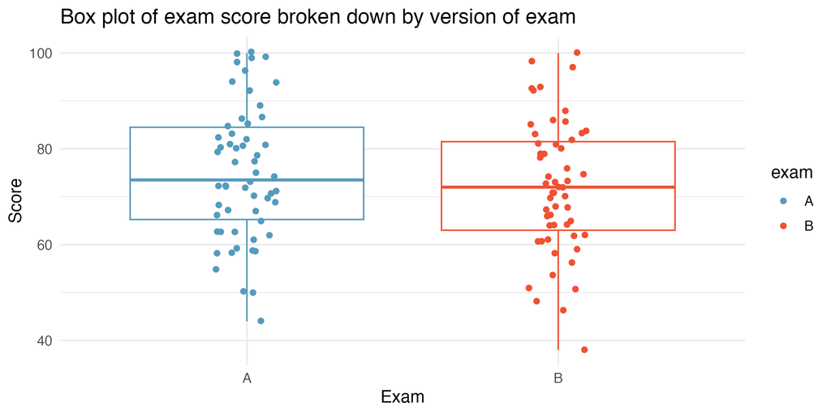

兩種試卷的分數並列；先看每組分布與組間平均差。

研究問題是兩種試卷的平均分數是否不同。

IMS 2e §20.1；Figure 20.1

## 課本圖例｜試卷標籤的一次重排

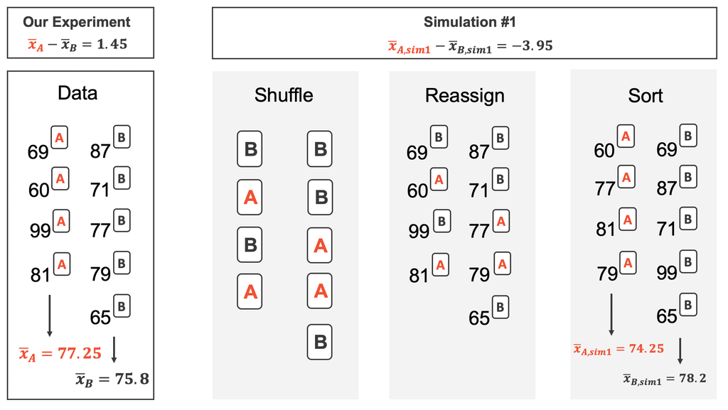

固定分數，依沒有試卷效果的虛無模型重新分派試卷標籤。

每次都應維持原分派設計所允許的組別結構。

IMS 2e §20.1；Figure 20.2

## 課本圖例｜很多次重排，很多個平均差

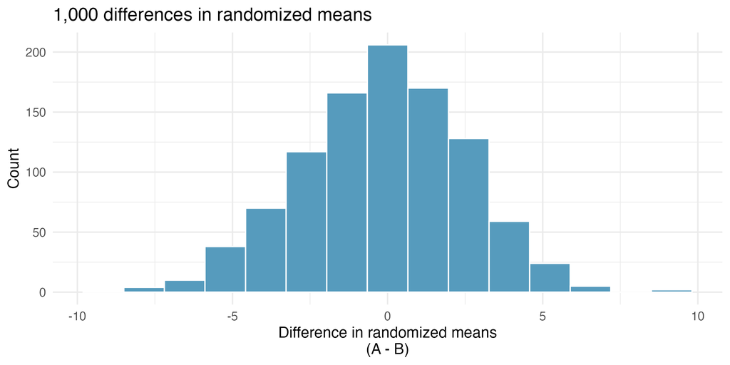

橫軸是平均差；每次重排重新計算，形成圖中的分布。

一筆原始分數和一個模擬平均差，是不同的觀察層次。

IMS 2e §20.1；Figure 20.3

## 課本圖例｜把觀察差放回參考分布

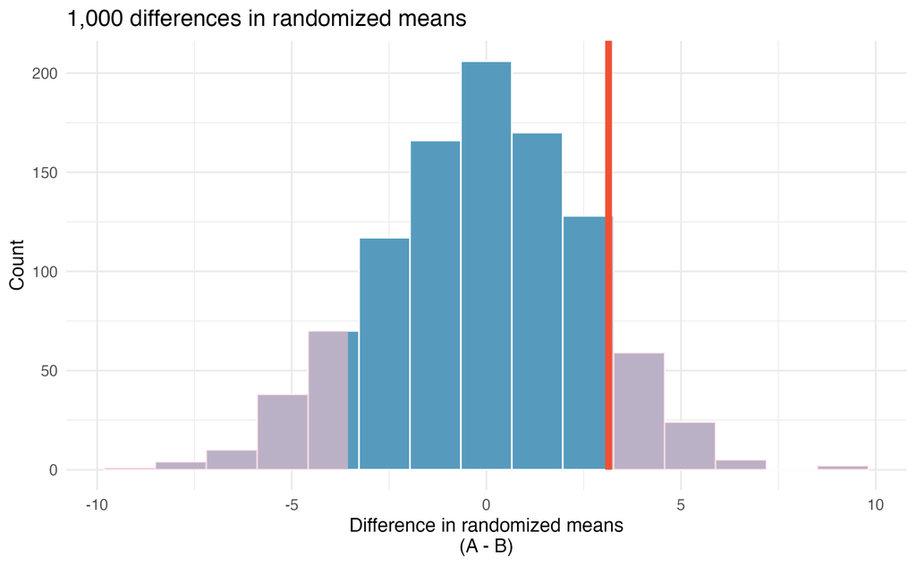

課本將觀察差約3.1分與虛無分布比較，陰影表示極端部分。

不要把課本1000次模擬，混成主例20種完整枚舉。

IMS 2e §20.1；Figure 20.4

## 課本圖例｜配對輪胎：每台車是連結

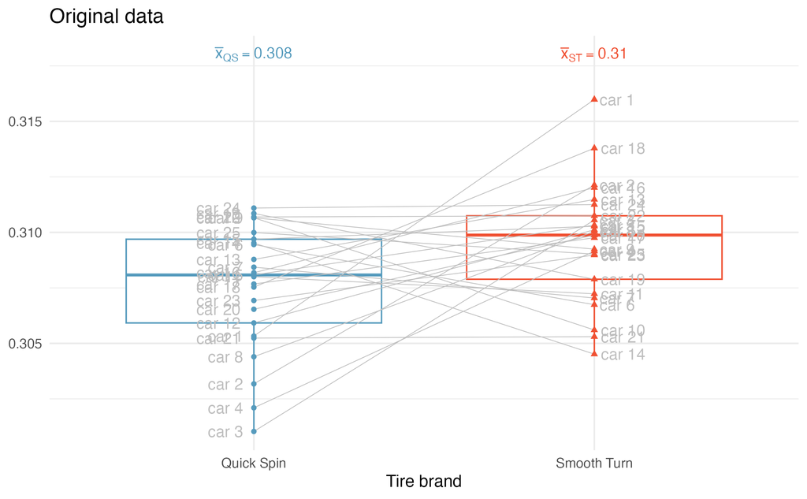

每台車都有兩品牌輪胎；圖先將各品牌胎紋厚度並列。

只看兩個箱型圖，不會完整顯示每台車的配對差。

IMS 2e §21.1；Figure 21.1

## 課本圖例｜同一台車內，標籤交換

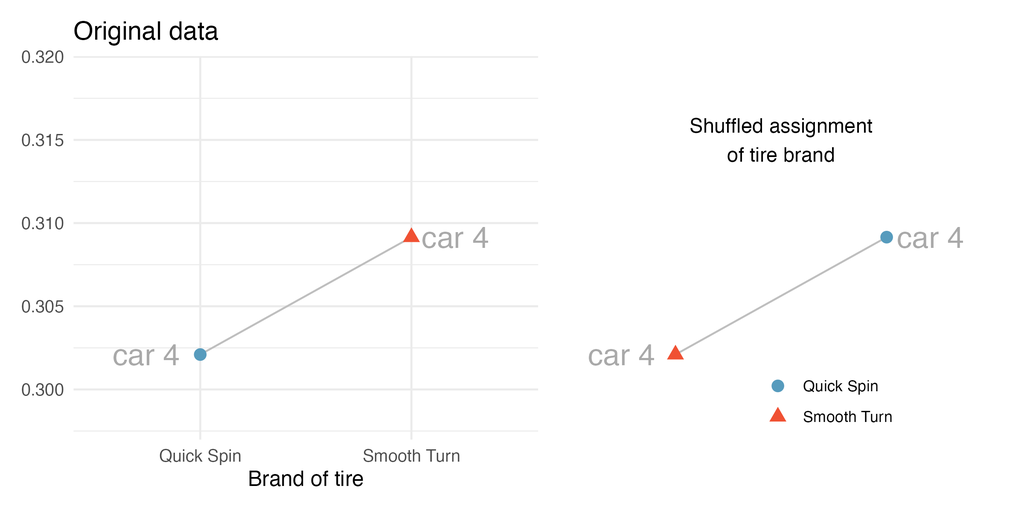

第4台車的兩筆胎紋量測留在同一對內，品牌標籤交換。

交換發生在車內；不是跨車任意混合。

IMS 2e §21.1；Figure 21.2

## 課本圖例｜同一台車內，也可能不交換

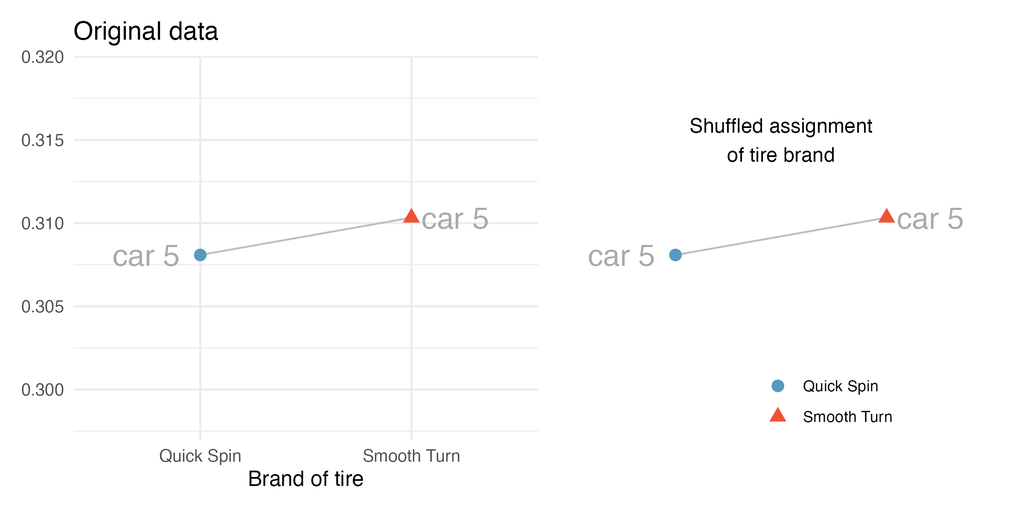

第5台車在這次重排保留原品牌標籤。

每一對可交換或保留，符合虛無模型與分派條件。

IMS 2e §21.1；Figure 21.3

## 課本圖例｜先保留原始配對

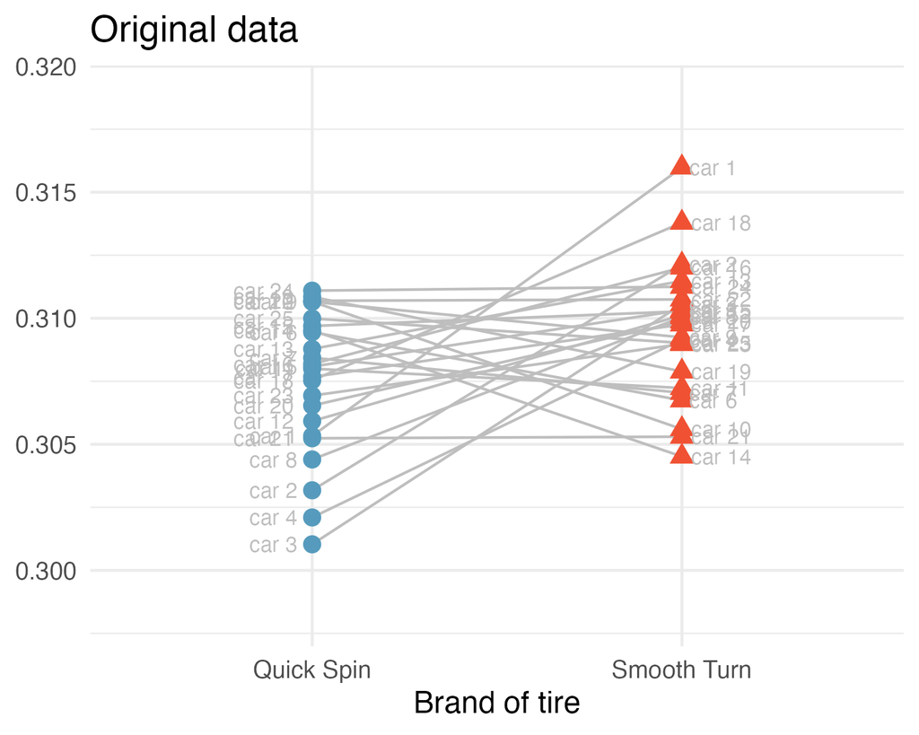

顏色與連線顯示同一台車的兩種輪胎，品牌是實際標籤。

配對結構在分析前就已存在。

IMS 2e §21.1；Figure 21.4a

## 課本圖例｜再看同一批車內的重派

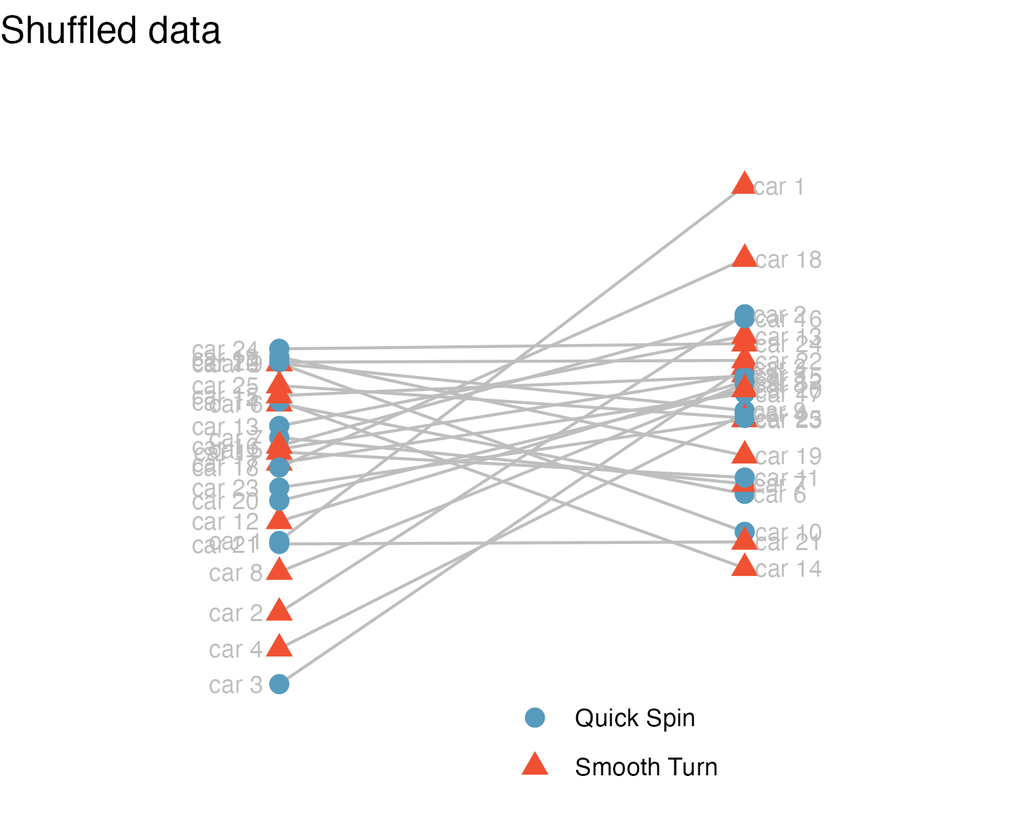

部分車內交換品牌標籤，部分保留；車與量測值都沒被換掉。

變的是標籤，保留的是車內連結。

IMS 2e §21.1；Figure 21.4b

## 課本圖例｜重派後先辨認標籤

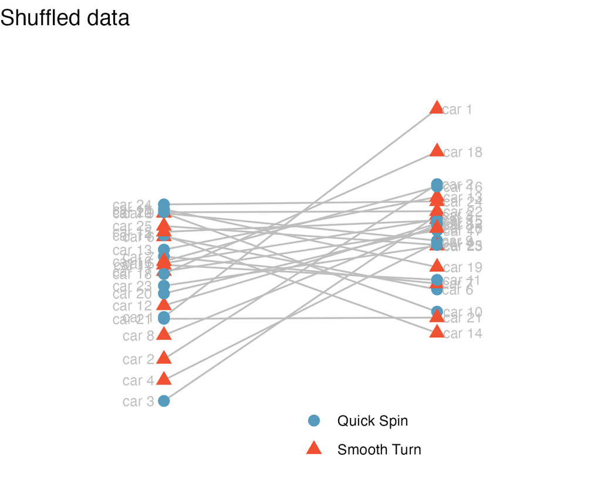

圖保留重派後的品牌指派，準備整理兩組數值。

先追蹤哪個值被指派到哪組。

IMS 2e §21.1；Figure 21.5a

## 課本圖例｜依新標籤整理，才算平均差

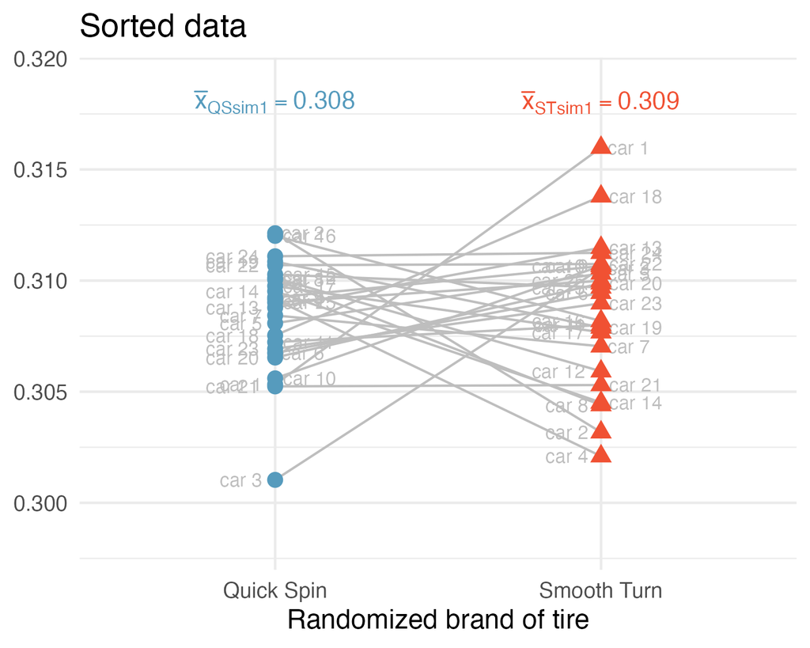

整理後的分組讓平均差可被計算；灰線仍連著同一台車。

排序只是讀圖與計算方便，不是另做一次隨機分派。

IMS 2e §21.1；Figure 21.5b

## 課本圖例｜第二次配對內重排

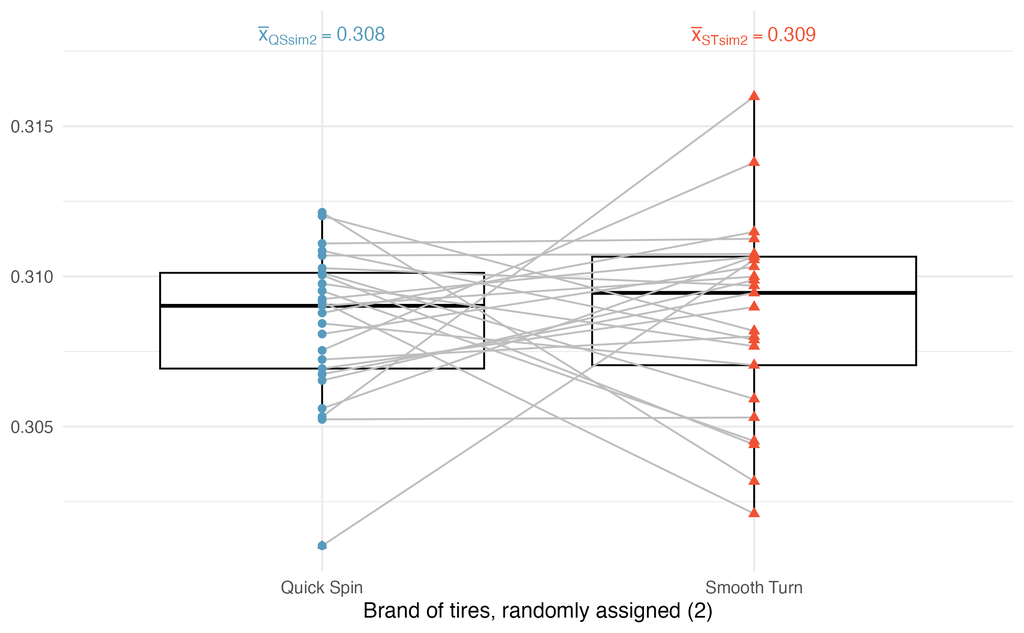

同一台車仍由灰線連結；這次交換的車可能和前次不同。

重複的是合法的配對內分派。

IMS 2e §21.1；Figure 21.6

## 課本圖例｜第三次配對內重排

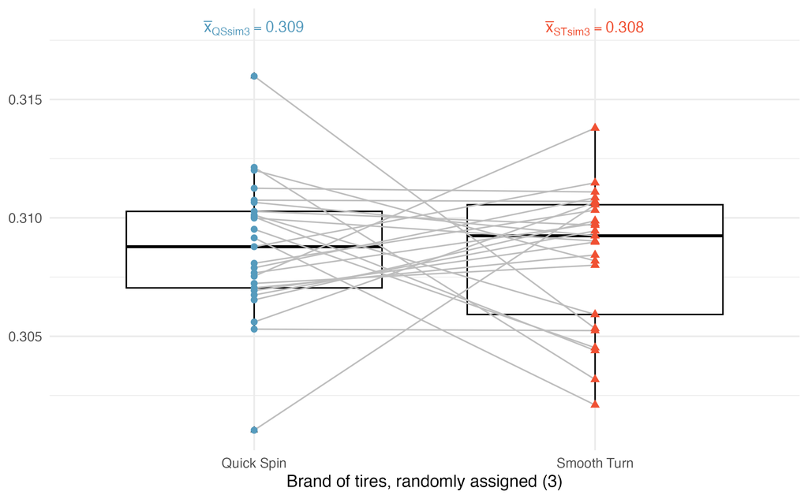

另一種配對內標籤分派產生另一個平均配對差。

不能把重排次數當成新增受試者人數。

IMS 2e §21.1；Figure 21.7

## 課本圖例｜配對平均差的虛無分布

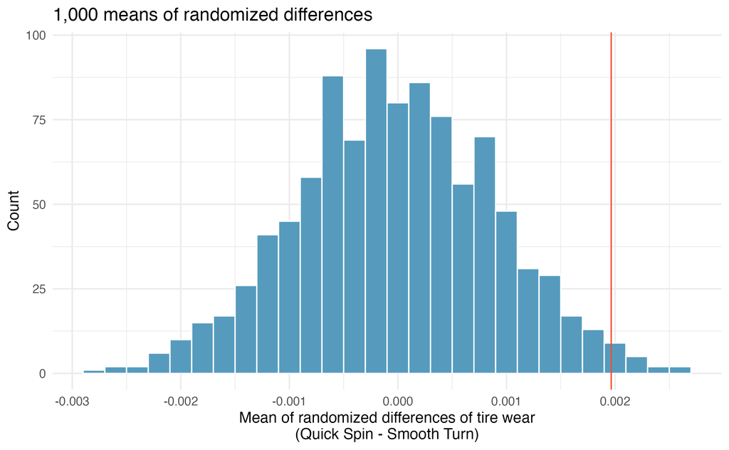

橫軸為平均配對差；垂直線標出課本觀察到的差。

主例與附錄都比較極端程度，但交換單位不同。

IMS 2e §21.1；Figure 21.8

## 課本圖例｜t 與標準常態的尾部比較

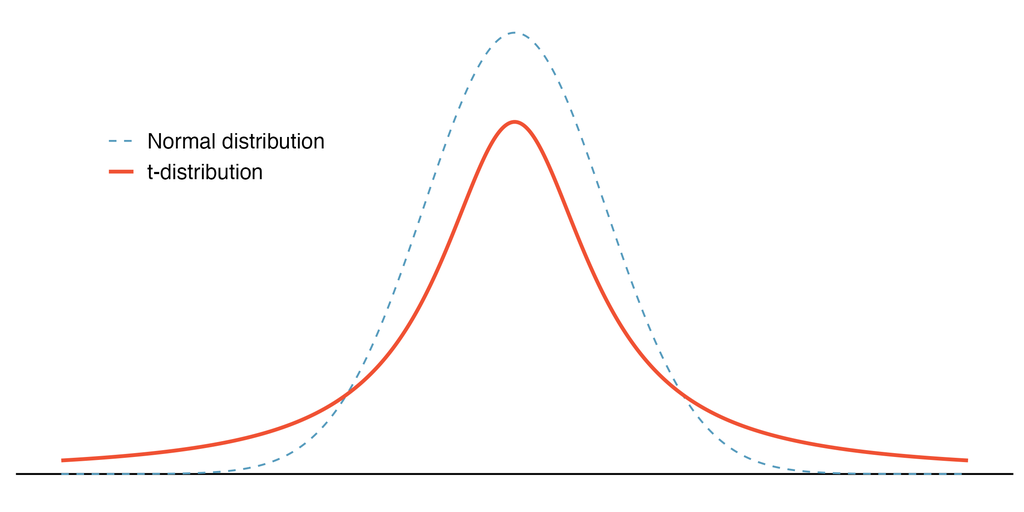

IMS Figure 19.8：t 與標準常態的尾部比較。

IMS 2e §19.2；Figure 19.8；CC BY-SA 3.0

## 課本圖例｜自由度增加時的 t 分布

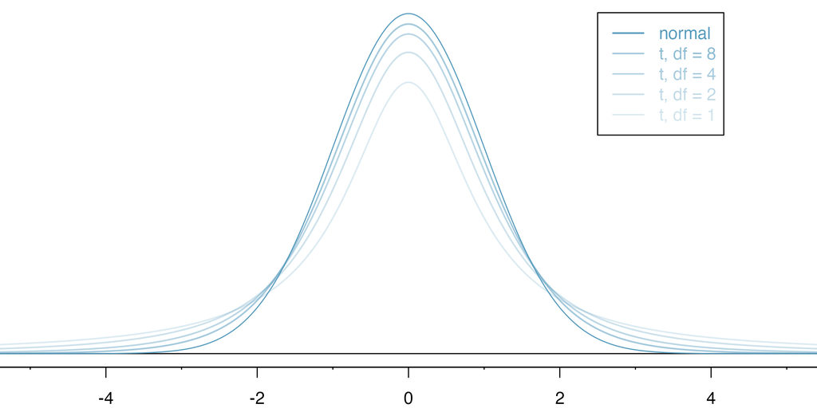

IMS Figure 19.9：自由度增加時的 t 分布。

IMS 2e §19.2；Figure 19.9；CC BY-SA 3.0

## 課本圖例｜兩獨立組分別 bootstrap，再計算平均差

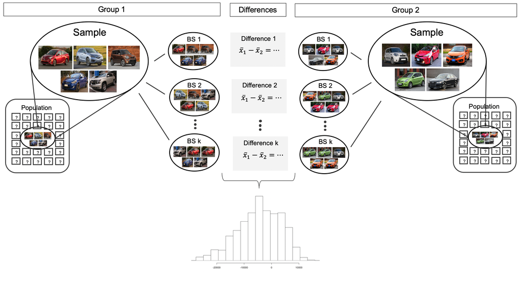

IMS Figure 20.5：兩獨立組分別 bootstrap，再計算平均差。

IMS 2e §20.2；Figure 20.5；CC BY-SA 3.0

## 課本圖例｜比較兩種 90% bootstrap 區間

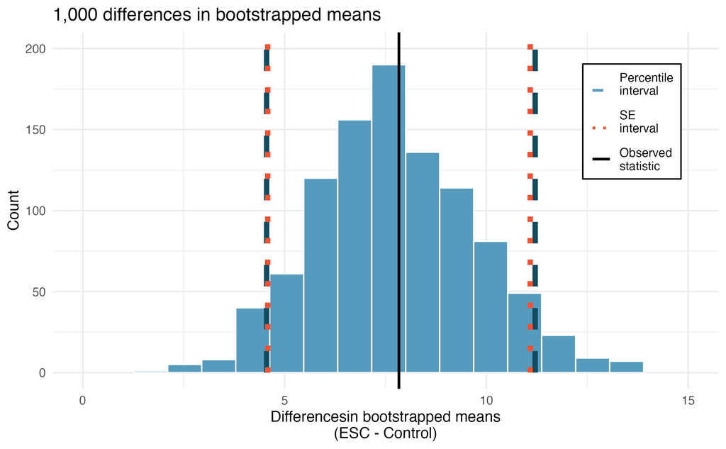

IMS Figure 20.6：比較兩種 90% bootstrap 區間。

IMS 2e §20.2；Figure 20.6；CC BY-SA 3.0

## 課本圖例｜出生體重依吸菸狀態分組

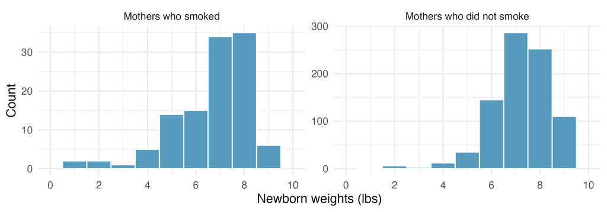

IMS Figure 20.7：出生體重依吸菸狀態分組。

IMS 2e §20.3；Figure 20.7；CC BY-SA 3.0

## 課本圖例｜兩組綿羊的心臟功能變化分布

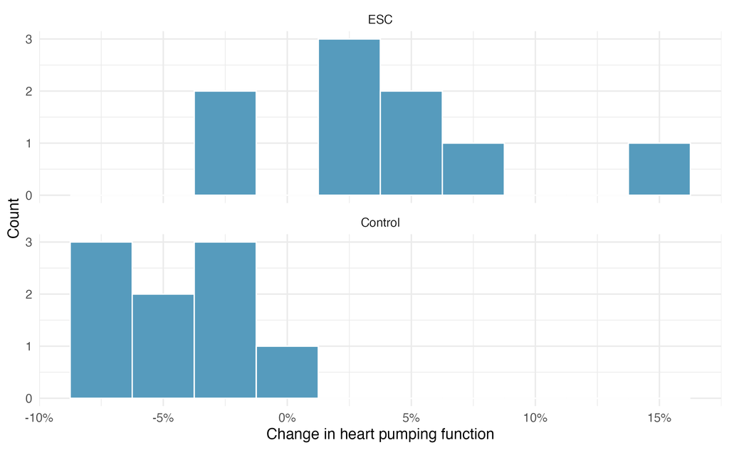

IMS Figure 20.8：兩組綿羊的心臟功能變化分布。

IMS 2e §20.4；Figure 20.8；CC BY-SA 3.0

## 課本圖例｜配對書價差的 bootstrap 區間

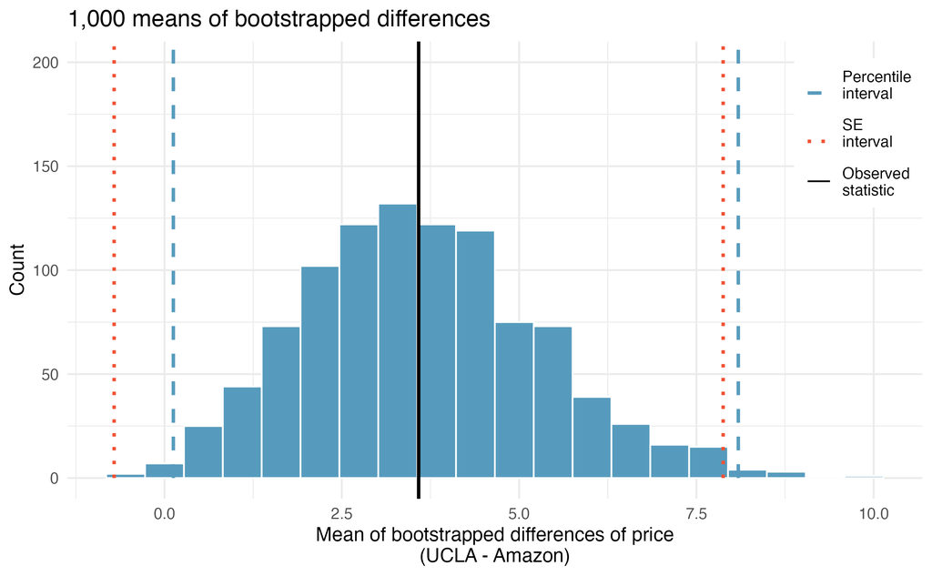

IMS Figure 21.9：配對書價差的 bootstrap 區間。

IMS 2e §21.2；Figure 21.9；CC BY-SA 3.0

## 課本圖例｜先相減，再看書價差的分布

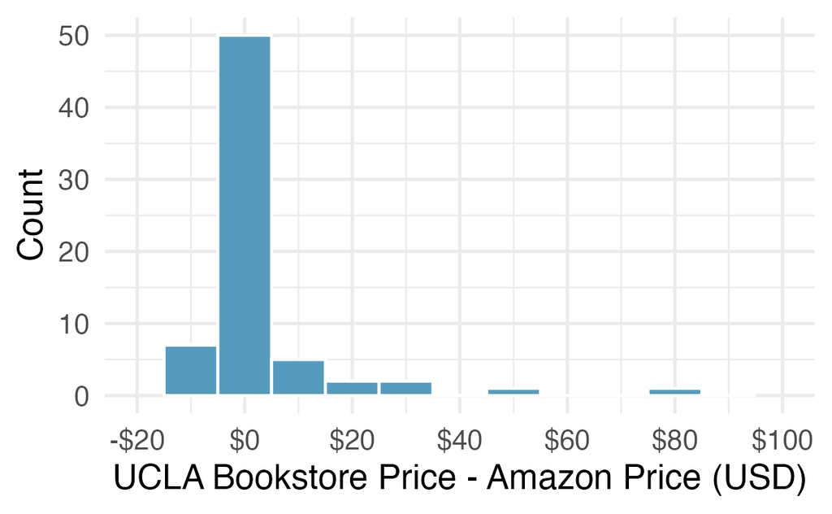

IMS Figure 21.10：先相減，再看書價差的分布。

IMS 2e §21.3；Figure 21.10；CC BY-SA 3.0